# Logistic_Regression-Optimization

南墙

2022.05.09

## 数据集说明

数据集包含学生GRE成绩和被录取的状态(admit = 1，为被录取；admit = 0，没有被录取)

```r
data <- read.csv("/mnt/d/Codefield/R/Statistical-Computing/homework/gredata.csv")
print(head(data))
```

```
#>   admit gre  gpa rank
#> 1     0 380 3.61    3
#> 2     1 660 3.67    3
#> 3     1 800 4.00    1
#> 4     1 640 3.19    4
#> 5     0 520 2.93    4
#> 6     1 760 3.00    2
```

## 逻辑回归的对数似然函数

令$y=admit, X=(1,gre,gpa,rank)=(X_{i1},X_{i2},X_{i3},X_{14}), \beta=(\beta_1,\beta_2,\beta_3,\beta_4)(i=1,2,\cdots,n;j=1,2,\cdots,m)$，设
$$p(y_i=1|X_i;\beta)=p(X_i)=\frac{e^{X_i \beta ^T}}{1+e^{X_i \beta ^T}}\\
p(y_i=0|X_i;\beta)=1-p(X_i)=\frac{1}{1+e^{X_i \beta ^T}}.$$
则似然函数为：
$$L(\beta) = \prod\limits_{i=1}^{n} {{{[p({X_i})]}^{{y_i}}}} {[1 - p({X_i})]^{1 - {y_i}}},$$
因此，逻辑回归的对数似然函数为：
$$\ell(\beta) = \sum\limits_{i=1}^{n} {\{ {y_i}\ln p({X_i}) + (1 - {y_i})\ln [1 - p({X_i})]} \}\\
= \sum\limits_{i=1}^{n} {\{ {y_i}\ln \frac{p({X_i})}{1-p({X_i})} + \ln [1 - p({X_i})]} \}\\
= \sum\limits_{i=1}^{n} {[ {y_i}(\beta ^T {X_i}) - \ln (1 + e^{\beta ^T {X_i}})}].$$

在R语言中，可写为这样的函数：

```r
loglikelogit <- function(beta) {
    Xb <- X %*% beta
    log1Xb <- log(1 + exp(Xb))
    loglike <- (t(y) %*% Xb) - sum(log1Xb)
    return(loglike)
}
```

## 对数似然函数的梯度函数

对数似然函数的梯度函数为：
$$\frac{\partial \ell(\beta)}{\partial \beta} = -\sum\limits_{i=1}^{n} {X_i(y_i-p(X_i))}$$

在R语言中，可写为这样的函数：

```r
gradlogit <- function(beta) {
    Xb <- X %*% beta
    pXb <- 1/(exp(-Xb) + 1)
    grad <- t(X) %*% (pXb - y)
    return(grad)
}
```

## 对数似然函数的海塞矩阵

对数似然函数的海塞矩阵为：
$$\frac{\partial^2 \ell(\beta)}{\partial \beta \partial \beta^T} = \sum\limits_{i=1}^{n} {X_i X_i^Tp(X_i;\beta)(1-p(X_i))}$$

在R语言中，可写为这样的函数：

```r
hessianlogit <- function(beta) {
    Xb <- X %*% beta
    weight <- exp(Xb)/((1 + exp(Xb))^2)
    diag <- diag(as.vector(weight))
    hessian <- t(X) %*% diag %*% X
    return(hessian)
}
```

## 使用`glm()`估计参数系数

使用R语言自带的逻辑回归函数`glm()`来估计逻辑回归的参数$\beta$。

R程序如下：

```r
glm.solve <- glm(formula = admit ~ gre + gpa + rank, data = data, family = binomial)
cat("glm()参数估计为", glm.solve$coefficients)
```

```
#> glm()参数估计为 -3.449548 0.00229396 0.7770136 -0.5600314
```

## 牛顿迭代算法与`glm()`比较

使用牛顿迭代算法求解逻辑回归参数的最优解，其第$t+1$轮的最优解如下：
$$\beta^{t+1} = \beta^{t}-\left({\frac{\partial^2 \ell(\beta)}{\partial \beta \partial \beta^T}}\right)^{-1}\frac{\partial \ell(\beta)}{\partial \beta}$$

R程序如下：

```r
y <- data$admit
X <- cbind(1, data$gre, data$gpa, data$rank)
beta <- solve(t(X) %*% X, t(X) %*% y)  # 初始值
epsilon <- 1e-10  # 误差限
MaxIter <- 500  # 最大迭代次数
i <- 1
betanew <- beta - solve(hessianlogit(beta), gradlogit(beta))
change <- abs(loglikelogit(betanew) - loglikelogit(beta))
while ((i <= MaxIter) && (change > epsilon)) {
    i <- i + 1
    beta <- cbind(beta, betanew)
    betanew <- beta[, i] - solve(hessianlogit(beta[, i]), gradlogit(beta[, i]))
    change <- abs(loglikelogit(betanew) - loglikelogit(beta[, i]))
}
beta <- cbind(beta, betanew)
cat("共迭代", i, "次", "\n")
```

```
#> 共迭代 5 次
```

```r
cat("牛顿迭代法系数估计为", betanew, "\n")
```

```
#> 牛顿迭代法系数估计为 -3.449548 0.00229396 0.7770136 -0.5600314
```

```r
cat("误差为", change)
```

```
#> 误差为 5.684342e-14
```

牛顿迭代算法迭代过程及结果与`glm()`求解结果对比

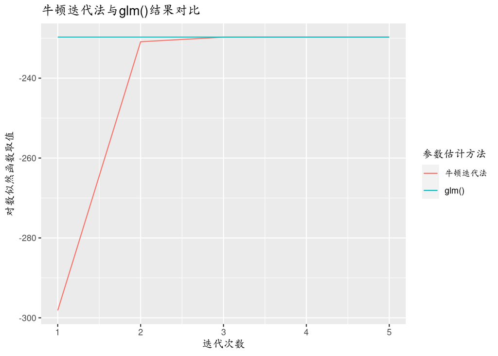

```r
library(ggplot2)
Newtonloglike <- outMatrix <- matrix(rep(NaN), i)
for (j in 1:i) {
    Newtonloglike[j] <- loglikelogit(beta[, j])
}
Newton.data <- data.frame(Iteration = c(1:i), Newtonloglike = matrix(Newtonloglike),
    glmloglike = matrix(rep(loglikelogit(glm.solve$coefficients)), i))
p <- ggplot(data = Newton.data)
p + geom_line(aes(x = Iteration, y = Newtonloglike, color = "牛顿迭代法")) +
    geom_line(aes(x = Iteration, y = glmloglike, color = "glm()")) + labs(title = "牛顿迭代法与glm()结果对比",
    x = "迭代次数", y = "对数似然函数取值") + guides(color = guide_legend(title = "参数估计方法"))
```

## 随机梯度下降算法与`glm()`比较

使用随机梯度下降算法求解逻辑回归参数的最优解，其第$t+1$轮的最优解如下：
$$\beta^{t+1} = \beta^{t}-\alpha \nabla J(\beta_i^{t})$$

R程序如下：

```r
y <- data$admit
X <- cbind(1, data$gre, data$gpa, data$rank)
n <- length(y)
sgd.logisticReg.cost.grad <- function(X, y, beta) {
    n <- length(y)
    if (!is.matrix(X)) {
        X <- matrix(X, nrow = 1)
    }
    t(X) %*% (1/(1 + exp(-X %*% beta)) - y)/n
}
beta <- c(-3.45, 0.002, 0.777, -0.56)  # 初始值
epsilon <- 1e-09  # 误差限
MaxIter <- 20000  # 最大迭代次数
alpha <- 1.5e-06  # 设定初始学习速率
n.samples <- 5  # 设定随机选取的样本量
i <- 1
sto.sample <- sample(1:n, n.samples, replace = TRUE)  # 选取的随机样本索引
betanew <- beta - alpha * sgd.logisticReg.cost.grad(X[sto.sample, ], y[sto.sample],
    beta)  # nolint
change <- abs(loglikelogit(betanew) - loglikelogit(beta))  # nolint
while ((i <= MaxIter) && (change > epsilon)) {
    i <- i + 1
    beta <- cbind(beta, betanew)
    alpha <- 1.5e-06/i + 2e-09  # 设定动态学习速率
    sto.sample <- sample(1:n, n.samples, replace = TRUE)
    betanew <- beta[, i] - alpha * sgd.logisticReg.cost.grad(X[sto.sample, ], y[sto.sample],
        beta[, i])  # nolint
    change <- abs(loglikelogit(betanew) - loglikelogit(beta[, i]))  # nolint
}
if (abs(loglikelogit(betanew) - loglikelogit(beta[, i])) > epsilon) {
    # nolint
    cat("算法无法收敛。 \n")
} else {
    cat("算法收敛\n")
    cat("共迭代", i, "次", "\n")
    cat("系数估计为：", betanew, "\n")
    cat("误差为", change)
    beta <- cbind(beta, betanew)
}
```

```
#> 算法收敛
#> 共迭代 2918 次
#> 系数估计为： -3.45 0.002285166 0.7770013 -0.5599996
#> 误差为 3.792024e-10
```

随机梯度下降算法迭代过程及结果与`glm()`求解结果对比

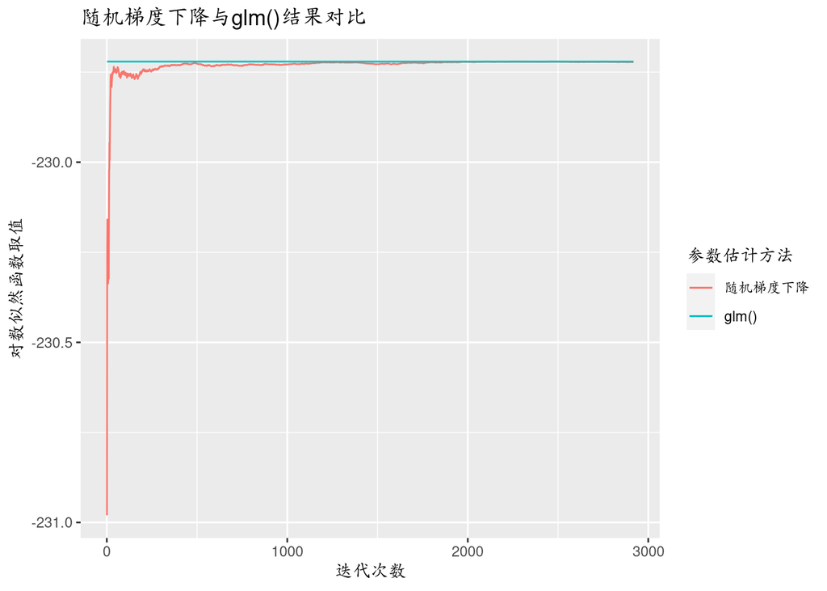

```r
library(ggplot2)
sgdloglike <- outMatrix <- matrix(rep(NaN), i)
for (j in 1:i) {
    sgdloglike[j] <- loglikelogit(beta[, j])
}
sgd.data <- data.frame(Iteration = c(1:i), sgdloglike = matrix(sgdloglike), glmloglike = matrix(rep(loglikelogit(glm.solve$coefficients)),
    i))
p <- ggplot(data = sgd.data)
p + geom_line(aes(x = Iteration, y = sgdloglike, color = "随机梯度下降")) +
    geom_line(aes(x = Iteration, y = glmloglike, color = "glm()")) + labs(title = "随机梯度下降与glm()结果对比",
    x = "迭代次数", y = "对数似然函数取值") + guides(color = guide_legend(title = "参数估计方法"))
```

注：由于对随机梯度下降理解还不够深，我随机梯度下降的代码运行起来有问题，会在迭代次数非常少的情况下就停止迭代，或者无法迭代到正确的值。光凭我个人的能力暂时看不出来是在哪里出了bug，若是老师看见这段话希望能帮我纠正一下，谢谢老师！